# Varighet av plager

Author

NNRR

## Flytdiagram for inklusjon av pasienter i analysen

**Click to see the code**

```r
library(nnrr)
library(dplyr)
library(tidyr)
library(scales)
library(ggplot2)
library(geepack)
library(emmeans)
library(DiagrammeR)
library(tibble)
library(glue)

datoTil <- "2024-12-31"
datoFra <- "2022-01-01"

raadata <- nnrr::nnrrHentRegData(datoFra = datoFra,
                                 datoTil = datoTil)

RegData <- raadata |>
  dplyr::filter(S1b_DateOfCompletion >= datoFra,
                S1b_DateOfCompletion <= datoTil,
                regstatus == 1,
                regstatus_pre == 1,
                regstatus_post == 1,
                regstatus_post2 == 1,
                PainDurationNow != "Ikke svart") |>
  dplyr::mutate(
    smertevarighet =ifelse(PainDurationNow == "Mer enn 2",
                           "Smerter > 2 år", "Smerter <= 2 år"),
    i_jobb_el_studier = S2_Working | S2_Student,
    arbledig_el_hjem = S2_Unemployed | S2_StayAtHome,
    aap_el_ufor = S2_NAV | S2_Pension,
    kun_post = ifelse(regstatus_post == 1 & regstatus_post2 == 0, 1, 0),
    kun_post2 = ifelse(regstatus_post == 0 & regstatus_post2 == 1, 1, 0),
    bedring_aktivitet = PainExperiencesActivity - PainExperiencesActivity_post >= 2,
    bedring_aktivitet2 = PainExperiencesActivity - PainExperiencesActivity_post2 >= 2
  ) |>
  dplyr::group_by(PasientGUID) |>
  dplyr::slice_max(
    S1b_DateOfCompletion,
    n = 1,
    with_ties = FALSE
  ) |>
  dplyr::ungroup()

RegData_1 <- raadata

RegData_4 <- RegData_1 |>
  filter(regstatus_post == 1)

RegData_5 <- RegData_4 |>
  filter(regstatus_post2 == 1)

RegData_6 <- RegData_5 |>
  filter(PainDurationNow != "Ikke svart")
RegData_7 <- RegData_6 |>
  dplyr::group_by(PasientGUID) |>
  dplyr::slice_max(
    S1b_DateOfCompletion,
    n = 1,
    with_ties = FALSE
  ) |>
  dplyr::ungroup()

filter_steps <- tibble(
  id = c("raw", "post", "post2", "pain", "dupl"),
  step = c(
    "Besvart pre-spørreskjema innenfor datoperiode",
    "Har besvart 6mnd post-spørreskjema",
    "Har besvart 12mnd post-spørreskjema",
    "Inkludert før fjerning av duplikater",
    "Inkludert i analysen"
  ),
  excluded_label = c(
    NA,
    "Ikke svart 6mnd post-spørreskjema",
    "Ikke svart 12mnd post-spørreskjema",
    "Ikke oppgitt smertevarighet",
    "Duplikater"
  ),
  n = c(
    nrow(RegData_1),
    nrow(RegData_4),
    nrow(RegData_5),
    nrow(RegData_6),
    nrow(RegData_7)
  )
) |>
  mutate(
    excluded = lag(n) - n,
    excluded = if_else(is.na(excluded), 0L, excluded)
  )

main_nodes <- glue(
  "{filter_steps$id} [label = '{filter_steps$step}\\nN = {filter_steps$n}']"
)

main_edges <- glue(
  "{filter_steps$id[-nrow(filter_steps)]} -> {filter_steps$id[-1]}"
)

excluded_steps <- filter_steps |>
  filter(id != "raw") |>
  mutate(
    from_id = filter_steps$id[-nrow(filter_steps)],
    to_id = id
  )

excluded_nodes <- glue(
  "excl_{excluded_steps$id} [label = '{excluded_steps$excluded_label}\\nEkskludert N = {excluded_steps$excluded}', shape = box]"
)

excluded_edges <- glue(
  "{excluded_steps$from_id} -> excl_{excluded_steps$id} [style = dashed, constraint = false]"
)

rank_pairs <- glue(
  "{{ rank = same; {excluded_steps$from_id}; excl_{excluded_steps$id}; }}"
)

grViz(glue("
digraph filtering_dag {{

  graph [
    layout = dot,
    rankdir = TB,
    splines = ortho
  ]

  node [
    shape = box,
    fontname = Helvetica,
    fontsize = 11
  ]

  edge [
    fontname = Helvetica,
    fontsize = 10
  ]

  {paste(main_nodes, collapse = '\n')}

  {paste(excluded_nodes, collapse = '\n')}

  {paste(main_edges, collapse = '\n')}

  {paste(excluded_edges, collapse = '\n')}

  {paste(rank_pairs, collapse = '\n')}
}}
"))
```

[interactive chart not shown]

## Deskriptiv analyse fra pasientskjema før behandling

Det er brukt enveis ANOVA for å sammenligne kontinuerlige variabler. For kategoriske variabler er det brukt Pearsons kji-kvadrat test.

Personer som ikke har svart på en variabel er ekskludert fra analysen for den aktuelle variabelen.

**Click to see the code**

```r
RegData_tab1 <- RegData

var_labels <- c(
  PatientAge = "Alder",
  PatientGender = "Kjønn",
  EducationLevel = "Utdanning",
  FamilyStatus = "Familiestatus",
  HSCL10Score = "Psykisk symptomtrykk (HSCL-10 skår)",
  FABQScore1 = "FABQ skår",
  OdiScore = "ODI skår",
  PainExperiencesActivity = "Smertepåvirkning på aktivitet",
  i_jobb_el_studier = "I arbeid eller studier",
  arbledig_el_hjem = "Arbeidsledig eller hjemme",
  S2_SickLeave = "Sykemeldt",
  aap_el_ufor = "På AAP eller ufør",
  S2_RetirementPension = "Alderspensjon",
  NofPainRegions = "Antall smerteregioner",
  VentetidFraHenvisningTilBesok = "Ventetid (dager)",
  PhysicalActivity = "Fysisk aktivitet"
)

names(RegData_tab1)[match(names(var_labels), names(RegData_tab1))] <- unname(var_labels)

factor_vars <- c(
  "Kjønn", "Utdanning", "Familiestatus",
  "I arbeid eller studier", "Arbeidsledig eller hjemme",
  "Sykemeldt", "På AAP eller ufør",
  "Alderspensjon", "Fysisk aktivitet"
)

RegData_tab1 <- RegData_tab1 |>
  mutate(
    Kjønn = factor(
      Kjønn,
      levels = c(1, 2),
      labels = c("Mann", "Kvinne")
    )
  ) |>
  mutate(
    across(
      all_of(factor_vars),
      ~ trimws(as.character(.x))
    )
  ) |>
  mutate(
    across(
      all_of(factor_vars),
      ~ ifelse(.x %in% c("Ikke svart", "Ikke besvart"), NA, .x)
    )
  ) |>
  mutate(
    `Fysisk aktivitet` = ifelse(`Fysisk aktivitet` == "0", NA, `Fysisk aktivitet`)
  ) |>
  mutate(
    across(
      all_of(factor_vars),
      factor
    )
  )

tab1 <- tableone::CreateTableOne(
  vars = c(
    "Alder", "Kjønn", "Utdanning",
    "Familiestatus", "Psykisk symptomtrykk (HSCL-10 skår)", "FABQ skår",
    "ODI skår", "Smertepåvirkning på aktivitet",
    "I arbeid eller studier", "Arbeidsledig eller hjemme",
    "Sykemeldt", "På AAP eller ufør",
    "Alderspensjon", "Antall smerteregioner",
    "Ventetid (dager)", "Fysisk aktivitet"
  ),
  strata = "smertevarighet",
  data = RegData_tab1,
  factorVars = factor_vars,
  addOverall = TRUE
)

tab1_out <- print(tab1, printToggle = FALSE)

knitr::kable(tab1_out[, -5])
```

Table 1: Sammenligningstabell etter smertevarighet

|  | Overall | Smerter <= 2 år | Smerter > 2 år | p |
| --- | --- | --- | --- | --- |
| n | 8364 | 4496 | 3868 |  |
| Alder (mean (SD)) | 49.50 (14.49) | 48.83 (14.66) | 50.28 (14.26) | <0.001 |
| Kjønn = Mann (%) | 3976 (47.5) | 2148 (47.8) | 1828 (47.3) | 0.653 |
| Utdanning (%) |  |  |  | 0.023 |
| Allmennfaglig videregående skole eller gymnas | 1042 (12.6) | 565 (12.6) | 477 (12.4) |  |
| Grunnskole 7-10 år, framhaldskole eller folkehøyskole | 1015 (12.2) | 507 (11.3) | 508 (13.3) |  |
| Høyskole eller universitet (4 år eller mer) | 1656 (20.0) | 918 (20.5) | 738 (19.3) |  |
| Høyskole eller universitet (mindre en 4 år) | 1725 (20.8) | 962 (21.5) | 763 (19.9) |  |
| Yrkesfaglig videregående skole, yrkesskole eller realskole | 2862 (34.5) | 1516 (33.9) | 1346 (35.1) |  |
| Familiestatus (%) |  |  |  | 0.082 |
| Enslig | 2351 (28.2) | 1252 (27.9) | 1099 (28.5) |  |
| Gift/Reg. partner | 4092 (49.1) | 2169 (48.4) | 1923 (49.9) |  |
| Samboende | 1891 (22.7) | 1059 (23.6) | 832 (21.6) |  |
| Psykisk symptomtrykk (HSCL-10 skår) (mean (SD)) | 2.05 (0.64) | 1.98 (0.63) | 2.14 (0.65) | <0.001 |
| FABQ skår (mean (SD)) | 14.10 (5.48) | 13.94 (5.41) | 14.30 (5.56) | 0.002 |
| ODI skår (mean (SD)) | 33.53 (15.08) | 32.27 (15.28) | 34.99 (14.71) | <0.001 |
| Smertepåvirkning på aktivitet (mean (SD)) | 6.73 (2.18) | 6.54 (2.24) | 6.95 (2.08) | <0.001 |
| I arbeid eller studier = TRUE (%) | 3937 (47.1) | 2155 (47.9) | 1782 (46.1) | 0.093 |
| Arbeidsledig eller hjemme = TRUE (%) | 360 ( 4.3) | 155 ( 3.4) | 205 ( 5.3) | <0.001 |
| Sykemeldt = TRUE (%) | 2706 (32.4) | 1821 (40.5) | 885 (22.9) | <0.001 |
| På AAP eller ufør = TRUE (%) | 1391 (16.6) | 448 (10.0) | 943 (24.4) | <0.001 |
| Alderspensjon = TRUE (%) | 1051 (12.6) | 542 (12.1) | 509 (13.2) | 0.137 |
| Antall smerteregioner (mean (SD)) | 7.18 (5.68) | 5.99 (4.74) | 8.57 (6.34) | <0.001 |
| Ventetid (dager) (mean (SD)) | 54.72 (36.68) | 51.22 (35.01) | 58.78 (38.12) | <0.001 |
| Fysisk aktivitet (%) |  |  |  | 0.002 |
| 1 | 1302 (15.8) | 641 (14.4) | 661 (17.4) |  |
| 2 | 5223 (63.3) | 2845 (64.0) | 2378 (62.6) |  |
| 3 | 1350 (16.4) | 748 (16.8) | 602 (15.8) |  |
| 4 | 370 ( 4.5) | 210 ( 4.7) | 160 ( 4.2) |  |

## Andel endring i ODI etter 6 mnd; pasienter med smertevarighet < og > 2 år ved baseline

**Click to see the code**

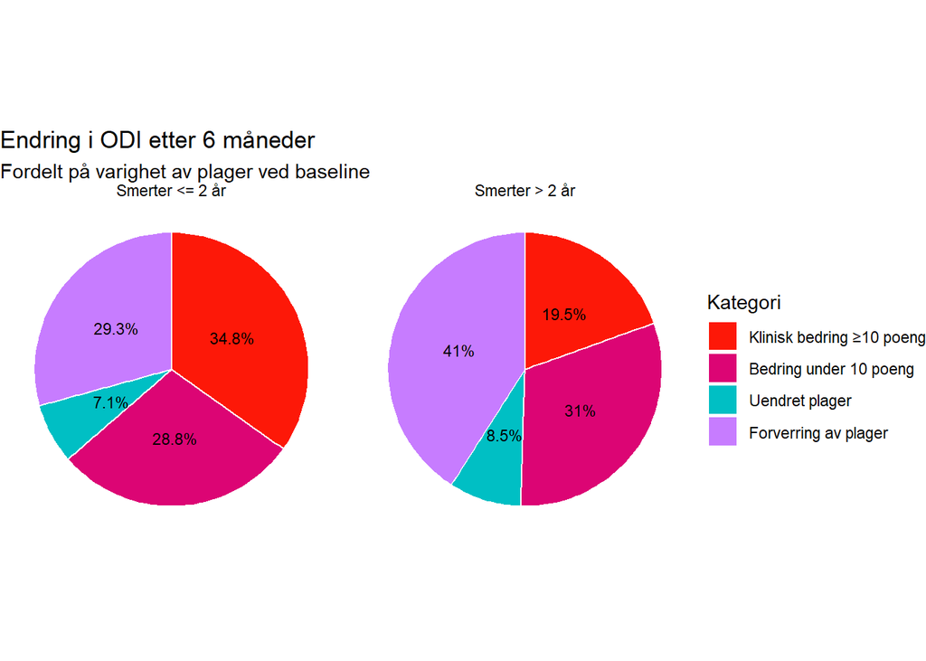

```r
kategori_levels <- c(
  "Forverring av plager",
  "Uendret plager",
  "Bedring under 10 poeng",
  "Klinisk bedring ≥10 poeng"
)

plot_data <- RegData |>
  transmute(
    smertevarighet,
    ODI_endring = OdiScore - OdiScore_post
  ) |>
  mutate(
    kategori = case_when(
      ODI_endring < 0 ~ "Forverring av plager",
      ODI_endring == 0 ~ "Uendret plager",
      ODI_endring > 0 & ODI_endring < 10 ~ "Bedring under 10 poeng",
      ODI_endring >= 10 ~ "Klinisk bedring ≥10 poeng",
      TRUE ~ NA_character_
    ),
    kategori = factor(kategori, levels = kategori_levels)
  ) |>
  filter(!is.na(kategori), !is.na(smertevarighet))

pie_data <- plot_data |>
  count(smertevarighet, kategori) |>
  group_by(smertevarighet) |>
  mutate(
    prosent = 100 * n / sum(n),
    label = paste0(round(prosent, 1), "%")
  ) |>
  ungroup()

ggplot(pie_data, aes(x = "", y = prosent, fill = kategori)) +
  geom_col(width = 1, color = "white") +
  coord_polar(theta = "y") +
  facet_wrap(~ smertevarighet) +
  geom_text(
    aes(label = label),
    position = position_stack(vjust = 0.5),
    size = 3
  ) +
  scale_fill_manual(
    values = c(
      "Forverring av plager" = "#C77CFF",
      "Uendret plager" = "#00BFC4",
      "Bedring under 10 poeng" = "#dc0574",
      "Klinisk bedring ≥10 poeng" = "#fd1808"
    ),
    guide = guide_legend(reverse = TRUE)
  ) +
  labs(
    title = "Endring i ODI etter 6 måneder",
    subtitle = "Fordelt på varighet av plager ved baseline",
    fill = "Kategori"
  ) +
  theme_void()
```

**Click to see the code**

```r
kontroll_tabell <- pie_data |>
  mutate(prosent = paste0(round(prosent, 1), "%")) |>
  select(
    `Varighet av plager` = smertevarighet,
    Kategori = kategori,
    Antall = n,
    Prosent = prosent
  ) |>
  arrange(`Varighet av plager`, Kategori)

knitr::kable(kontroll_tabell)
```

| Varighet av plager | Kategori | Antall | Prosent |
| --- | --- | --- | --- |
| Smerter <= 2 år | Forverring av plager | 1278 | 29.3% |
| Smerter <= 2 år | Uendret plager | 310 | 7.1% |
| Smerter <= 2 år | Bedring under 10 poeng | 1257 | 28.8% |
| Smerter <= 2 år | Klinisk bedring ≥10 poeng | 1520 | 34.8% |
| Smerter > 2 år | Forverring av plager | 1534 | 41% |
| Smerter > 2 år | Uendret plager | 320 | 8.5% |
| Smerter > 2 år | Bedring under 10 poeng | 1159 | 31% |
| Smerter > 2 år | Klinisk bedring ≥10 poeng | 731 | 19.5% |

## Andeler ved baseline

#### Antall pasienter som ikke har besvart smerte eller ODI på oppfølgingsskjema ved baseline, 6 og 12 måneder

**Click to see the code**

```r
not_answered <- RegData |>
  summarise(
    `ikke besvart NSR baseline` = sum(is.na(PainExperiencesActivity)),
    `ikke besvart NSR 6 mnd` = sum(is.na(PainExperiencesActivity_post)),
    `ikke besvart NSR 12 mnd` = sum(is.na(PainExperiencesActivity_post2)),
    `ikke besvart ODI baseline` = sum(is.na(OdiScore)),
    `ikke besvart ODI 6 mnd` = sum(is.na(OdiScore_post)),
    `ikke besvart ODI 12 mnd` = sum(is.na(OdiScore_post2))
  )
knitr::kable(not_answered)
```

| ikke besvart NSR baseline | ikke besvart NSR 6 mnd | ikke besvart NSR 12 mnd | ikke besvart ODI baseline | ikke besvart ODI 6 mnd | ikke besvart ODI 12 mnd |
| --- | --- | --- | --- | --- | --- |
| 100 | 46 | 93 | 38 | 222 | 242 |

### Andel med klinisk viktig bedring i smerte i aktivitet etter 6 mnd og 12 mnd; pasienter med smertevarighet < og > 2 år ved baseline

**Click to see the code**

```r
prop_ci <- function(x, n) {
  if (is.na(n) || n == 0) {
    return(c(NA_real_, NA_real_))
  }

  prop.test(x, n)$conf.int
}

safe_p <- function(gruppe, utfall) {
  dat <- data.frame(
    gruppe = gruppe,
    utfall = utfall
  ) |>
    filter(
      !is.na(gruppe),
      !is.na(utfall)
    ) |>
    mutate(
      gruppe = droplevels(as.factor(gruppe)),
      utfall = factor(utfall, levels = c(0, 1))
    )

  tab <- table(dat$gruppe, dat$utfall)

  if (nrow(tab) < 2 || ncol(tab) < 2) {
    return(NA_real_)
  }

  suppressWarnings(chisq.test(tab)$p.value)
}

format_p <- function(p) {
  ifelse(
    is.na(p),
    "",
    format.pval(p, digits = 3, eps = 0.001)
  )
}

andel_data <- RegData |>
  mutate(
    smertevarighet = factor(
      smertevarighet,
      levels = c("Smerter <= 2 år", "Smerter > 2 år")
    ),
    smerte_baseline = PainExperiencesActivity,
    ODI_baseline = OdiScore
  ) |>
  transmute(
    smertevarighet,
    smerte_baseline,
    ODI_baseline,
    `6 måneder aktivitet` = PainExperiencesActivity_post,
    `12 måneder aktivitet` = PainExperiencesActivity_post2,
    `6 måneder ODI` = OdiScore_post,
    `12 måneder ODI` = OdiScore_post2
  )

andel_data_activity <- andel_data |>
  pivot_longer(
    cols = c(`6 måneder aktivitet`, `12 måneder aktivitet`),
    names_to = "tidspunkt",
    values_to = "smerte_oppfolging"
  ) |>
  mutate(
    tidspunkt = case_when(
      tidspunkt == "6 måneder aktivitet" ~ "6 måneder",
      tidspunkt == "12 måneder aktivitet" ~ "12 måneder",
      TRUE ~ tidspunkt
    ),
    tidspunkt = factor(
      tidspunkt,
      levels = c("6 måneder", "12 måneder")
    ),
    smertereduksjon = smerte_baseline - smerte_oppfolging,
    klinisk_viktig_bedring = case_when(
      is.na(smertereduksjon) ~ NA_integer_,
      smertereduksjon >= 2 ~ 1L,
      TRUE ~ 0L
    )
  )

andel_data_odi <- andel_data |>
  pivot_longer(
    cols = c(`6 måneder ODI`, `12 måneder ODI`),
    names_to = "tidspunkt",
    values_to = "odi_oppfolging"
  ) |>
  mutate(
    tidspunkt = case_when(
      tidspunkt == "6 måneder ODI" ~ "6 måneder",
      tidspunkt == "12 måneder ODI" ~ "12 måneder",
      TRUE ~ tidspunkt
    ),
    tidspunkt = factor(
      tidspunkt,
      levels = c("6 måneder", "12 måneder")
    ),
    odi_endring = ODI_baseline - odi_oppfolging,
    klinisk_viktig_bedring = case_when(
      is.na(odi_endring) ~ NA_integer_,
      odi_endring >= 10 ~ 1L,
      TRUE ~ 0L
    )
  )

andel_tabell_activity <- andel_data_activity |>
  group_by(tidspunkt, smertevarighet) |>
  summarise(
    N = sum(!is.na(klinisk_viktig_bedring)),
    n_bedring = sum(klinisk_viktig_bedring == 1, na.rm = TRUE),
    ci_lower = prop_ci(n_bedring, N)[1],
    ci_upper = prop_ci(n_bedring, N)[2],
    .groups = "drop"
  ) |>
  mutate(
    verdi = sprintf(
      "%s/%s (%.1f%%)<br>(%.1f–%.1f%%)",
      n_bedring,
      N,
      100 * n_bedring / N,
      100 * ci_lower,
      100 * ci_upper
    )
  )

p_values_activity <- andel_data_activity |>
  filter(!is.na(klinisk_viktig_bedring)) |>
  group_by(tidspunkt) |>
  summarise(
    p_value = safe_p(smertevarighet, klinisk_viktig_bedring),
    .groups = "drop"
  )

final_tabell_activity <- andel_tabell_activity |>
  select(
    tidspunkt,
    smertevarighet,
    verdi
  ) |>
  pivot_wider(
    names_from = smertevarighet,
    values_from = verdi
  ) |>
  left_join(p_values_activity, by = "tidspunkt") |>
  mutate(
    Rad = "Andel med<br>klinisk viktig<br>bedring",
    `P-verdi` = format_p(p_value)
  ) |>
  select(
    tidspunkt,
    Rad,
    `Smerter <= 2 år`,
    `Smerter > 2 år`,
    `P-verdi`
  ) |>
  arrange(tidspunkt)

final_tabell_activity |>
  knitr::kable(
    format = "html",
    escape = FALSE,
    col.names = c(
      "",
      "",
      "Smerter < 2 år (%)<br>(KI)",
      "Smerter > 2 år (%)<br>(KI)",
      "P-verdi"
    ),
    align = c("l", "l", "c", "c", "c")
  ) |>
  kableExtra::kable_styling(
    full_width = FALSE,
    bootstrap_options = c("condensed")
  ) |>
  kableExtra::column_spec(1, width = "7em") |>
  kableExtra::column_spec(2, width = "12em") |>
  kableExtra::column_spec(3, width = "13em") |>
  kableExtra::column_spec(4, width = "13em") |>
  kableExtra::column_spec(5, width = "6em")
```

|  |  | Smerter < 2 år (%) (KI) | Smerter > 2 år (%) (KI) | P-verdi |
| --- | --- | --- | --- | --- |
| 6 måneder | Andel med klinisk viktig bedring | 2110/4425 (47.7%) (46.2–49.2%) | 1413/3796 (37.2%) (35.7–38.8%) | <0.001 |
| 12 måneder | Andel med klinisk viktig bedring | 2185/4398 (49.7%) (48.2–51.2%) | 1430/3776 (37.9%) (36.3–39.4%) | <0.001 |

### Andel med klinisk viktig bedring i ODI etter 6 mnd og 12 mnd; pasienter med smertevarighet < og > 2 år ved baseline

**Click to see the code**

```r
andel_tabell_odi <- andel_data_odi |>
  group_by(tidspunkt, smertevarighet) |>
  summarise(
    N = sum(!is.na(klinisk_viktig_bedring)),
    n_bedring = sum(klinisk_viktig_bedring == 1, na.rm = TRUE),
    ci_lower = prop_ci(n_bedring, N)[1],
    ci_upper = prop_ci(n_bedring, N)[2],
    .groups = "drop"
  ) |>
  mutate(
    verdi = sprintf(
      "%s/%s (%.1f%%)<br>(%.1f–%.1f%%)",
      n_bedring,
      N,
      100 * n_bedring / N,
      100 * ci_lower,
      100 * ci_upper
    )
  )

p_values_odi <- andel_data_odi |>
  filter(!is.na(klinisk_viktig_bedring)) |>
  group_by(tidspunkt) |>
  summarise(
    p_value = safe_p(smertevarighet, klinisk_viktig_bedring),
    .groups = "drop"
  )

final_tabell_odi <- andel_tabell_odi |>
  select(
    tidspunkt,
    smertevarighet,
    verdi
  ) |>
  pivot_wider(
    names_from = smertevarighet,
    values_from = verdi
  ) |>
  left_join(p_values_odi, by = "tidspunkt") |>
  mutate(
    Rad = "Andel med<br>klinisk viktig<br>bedring",
    `P-verdi` = format_p(p_value)
  ) |>
  select(
    tidspunkt,
    Rad,
    `Smerter <= 2 år`,
    `Smerter > 2 år`,
    `P-verdi`
  ) |>
  arrange(tidspunkt)

final_tabell_odi |>
  knitr::kable(
    format = "html",
    escape = FALSE,
    col.names = c(
      "",
      "",
      "Smerter < 2 år (%)<br>(KI)",
      "Smerter > 2 år (%)<br>(KI)",
      "P-verdi"
    ),
    align = c("l", "l", "c", "c", "c")
  ) |>
  kableExtra::kable_styling(
    full_width = FALSE,
    bootstrap_options = c("condensed")
  ) |>
  kableExtra::column_spec(1, width = "7em") |>
  kableExtra::column_spec(2, width = "12em") |>
  kableExtra::column_spec(3, width = "13em") |>
  kableExtra::column_spec(4, width = "13em") |>
  kableExtra::column_spec(5, width = "6em")
```

|  |  | Smerter < 2 år (%) (KI) | Smerter > 2 år (%) (KI) | P-verdi |
| --- | --- | --- | --- | --- |
| 6 måneder | Andel med klinisk viktig bedring | 1520/4365 (34.8%) (33.4–36.3%) | 731/3744 (19.5%) (18.3–20.8%) | <0.001 |
| 12 måneder | Andel med klinisk viktig bedring | 1707/4371 (39.1%) (37.6–40.5%) | 835/3719 (22.5%) (21.1–23.8%) | <0.001 |

## Korrigert analyse med GEE-modell

P-verdiene i Table 1 viser om pasientene med kort og lang smertevarighet skiller seg fra hverandre på baselinevariabler. Dette gir nyttig deskriptiv informasjon og kan bidra til å synliggjøre eventuell ubalanse mellom gruppene. Samtidig bør p-verdiene ikke alene være avgjørende for hvilke variabler som inkluderes som justeringsvariabler i GEE-modellen.

Ved valg av justeringsvariabler er hovedmålet å redusere mulig bias, særlig knyttet til konfunderende faktorer. En variabel kan være statistisk signifikant forskjellig mellom gruppene uten nødvendigvis å være en viktig konfunderende faktor. Tilsvarende kan en klinisk relevant variabel, for eksempel alder eller kjønn, være ikke-signifikant i Table 1, men likevel være relevant å justere for dersom den kan påvirke smerteforløp eller sannsynligheten for klinisk viktig bedring.

Det er derfor ikke tilstrekkelig at en variabel er ulikt fordelt mellom gruppene. Variabelen bør også være klinisk eller metodisk relevant for utfallet, og plausibelt kunne påvirke både gruppetilhørighet og prognose. I store datasett kan dessuten små og klinisk lite viktige forskjeller bli statistisk signifikante. Dersom alle signifikante variabler inkluderes automatisk, kan modellen bli mer datadrevet enn faglig begrunnet.

Målet med justeringen er derfor ikke å korrigere for alle observerte forskjeller mellom gruppene, men å gjøre sammenligningen mer rettferdig med hensyn til faktorer som kan gi skjevhet i estimatet. Valg av variabler bør derfor bygge på det vi mener er faktorer som er relevante prognostiske eller konfunderende variabler, uten å inkludere mulige mediatorer unødig.

#### GEE kort forklart

OR-tabellen viser sammenhengen mellom ulike faktorer og sannsynligheten for klinisk viktig bedring. Fordi samme pasient inngår med målinger ved både 6 og 12 måneder, bruker vi GEE i stedet for vanlig logistisk regresjon. GEE tar hensyn til at observasjoner fra samme pasient er korrelerte, og gir derfor mer korrekte standardfeil, konfidensintervall og p-verdier. Grunnen til at vi tar hensyn til korrelasjon er at en pasients bedring ved 6 måneder i stor grad kan være relatert til bedring ved 12 måneder. Hvis vi ignorerer denne korrelasjonen, kan vi undervurdere usikkerheten i estimatene og dermed få for smale konfidensintervall og feilaktige p-verdier. Odds ratioene kan ligne på dem vi ville fått fra vanlig logistisk regresjon, men GEE gir en riktigere vurdering av usikkerheten rundt estimatene. OR-ene tolkes som gjennomsnittlige sammenhenger på gruppenivå, ikke som individuelle pasientspesifikke effekter.

### Oddsratio for klinisk viktig bedring i smerte etter 6 mnd og 12 mnd mellom pasienter med smertevarighet < og > 2 år ved baseline

**Click to see the code**

```r
gee_data_activity <- RegData |>
  transmute(
    PasientGUID,
    smertevarighet,
    smerte_baseline = PainExperiencesActivity,
    `6 måneder` = PainExperiencesActivity_post,
    `12 måneder` = PainExperiencesActivity_post2,
    NofPainRegions,
    HSCL10Score,
    FABQScore1,
    EducationLevel,
    PatientAge,
    PatientGender
  ) |>
  pivot_longer(
    cols = c(`6 måneder`, `12 måneder`),
    names_to = "tidspunkt",
    values_to = "smerte_oppfolging"
  ) |>
  mutate(
    tidspunkt = factor(tidspunkt, levels = c("6 måneder", "12 måneder")),
    smertevarighet = factor(
      smertevarighet,
      levels = c("Smerter <= 2 år", "Smerter > 2 år")
    ),
    smertereduksjon = smerte_baseline - smerte_oppfolging,
    klinisk_viktig_bedring = case_when(
      is.na(smertereduksjon) ~ NA_integer_,
      smertereduksjon >= 2 ~ 1L,
      TRUE ~ 0L
    ),
    EducationLevel = ifelse(EducationLevel == "Ikke svart", NA, EducationLevel)
  ) |>
  filter(
    !is.na(PasientGUID),
    !is.na(klinisk_viktig_bedring),
    !is.na(smertevarighet),
    !is.na(smerte_baseline),
    !is.na(NofPainRegions),
    !is.na(HSCL10Score),
    !is.na(FABQScore1),
    !is.na(EducationLevel),
    !is.na(PatientAge),
    !is.na(PatientGender)
  ) |>
  mutate(
    across(
      c(
        PatientGender,
        EducationLevel,
      ),
      as.factor
    )
  )
smerte_baseline_below_2 <- gee_data_activity |>
  filter(smerte_baseline < 2) |>
    distinct(PasientGUID)
str <- glue("Antall pasienter med smerte_baseline < 2: {nrow(smerte_baseline_below_2)}.
Disse ble eksludert fra analysen.")
print(str)
```

```
Antall pasienter med smerte_baseline < 2: 165.
Disse ble eksludert fra analysen.
```

**Click to see the code**

```r
gee_data_activity <- gee_data_activity |>
  filter(smerte_baseline >= 2)

gee_data_activity <- gee_data_activity |>
  mutate(across(where(is.factor), droplevels)) |>
  arrange(PasientGUID, tidspunkt)  |>
  mutate(
    cluster_id = as.integer(factor(PasientGUID))
  )

str2 <- glue(
    "geeglm() er en complete-case analyse.
    Antall pasienter med komplette rader for denne analysen er:
    {n_distinct(gee_data_activity$PasientGUID)}."
  )
print(str2)
```

```
geeglm() er en complete-case analyse.
Antall pasienter med komplette rader for denne analysen er:
7976.
```

**Click to see the code**

```r
gee_activity <- geeglm(
  klinisk_viktig_bedring ~
    smertevarighet * tidspunkt +
    smerte_baseline +
    NofPainRegions +
    HSCL10Score +
    FABQScore1 +
    EducationLevel +
    PatientAge +
    PatientGender,
  id = cluster_id,
  data = gee_data_activity,
  family = binomial(link = "logit"),
  corstr = "exchangeable"
)


or_activity <- emmeans(
  gee_activity,
  pairwise ~ smertevarighet | tidspunkt,
  type = "response"
)

or_tabell_activity <- summary(
  or_activity$contrasts,
  infer = TRUE,
  type = "response"
) |>
  as.data.frame() |>
  mutate(
    OR = sprintf("%.2f", odds.ratio),
    KI_95 = sprintf("%.2f–%.2f", lower.CL, upper.CL),
    p_verdi = format.pval(p.value, digits = 3, eps = 0.001)
  ) |>
  select(
    tidspunkt,
    Sammenligning = contrast,
    OR,
    `95 % KI` = KI_95,
    `P-verdi` = p_verdi
  )

knitr::kable(or_tabell_activity)
```

| tidspunkt | Sammenligning | OR | 95 % KI | P-verdi |
| --- | --- | --- | --- | --- |
| 6 måneder | Smerter <= 2 år / Smerter > 2 år | 1.63 | 1.48–1.79 | <0.001 |
| 12 måneder | Smerter <= 2 år / Smerter > 2 år | 1.75 | 1.59–1.92 | <0.001 |

### Oddsratio for klinisk viktig bedring i ODI etter 6 mnd og 12 mnd mellom pasienter med smertevarighet < og > 2 år ved baseline

**Click to see the code**

```r
gee_data_odi <- RegData |>
  transmute(
    PasientGUID,
    smertevarighet,
    odi_baseline = OdiScore,
    `6 måneder` = OdiScore_post,
    `12 måneder` = OdiScore_post2,
    NofPainRegions,
    HSCL10Score,
    FABQScore1,
    EducationLevel,
    PatientAge,
    PatientGender
  ) |>
  pivot_longer(
    cols = c(`6 måneder`, `12 måneder`),
    names_to = "tidspunkt",
    values_to = "odi_oppfolging"
  ) |>
  mutate(
    tidspunkt = factor(tidspunkt, levels = c("6 måneder", "12 måneder")),
    smertevarighet = factor(
      smertevarighet,
      levels = c("Smerter <= 2 år", "Smerter > 2 år")
    ),
    odi_endring = odi_baseline - odi_oppfolging,
    klinisk_viktig_bedring = case_when(
      is.na(odi_endring) ~ NA_integer_,
      odi_endring >= 10 ~ 1L,
      TRUE ~ 0L
    ),
    EducationLevel = ifelse(EducationLevel == "Ikke svart", NA, EducationLevel)
  ) |>
  filter(
    !is.na(PasientGUID),
    !is.na(klinisk_viktig_bedring),
    !is.na(smertevarighet),
    !is.na(odi_baseline),
    !is.na(NofPainRegions),
    !is.na(HSCL10Score),
    !is.na(FABQScore1),
    !is.na(EducationLevel),
    !is.na(PatientAge),
    !is.na(PatientGender)
  ) |>
  mutate(
    across(
      c(
        PatientGender,
        EducationLevel,
      ),
      as.factor
    )
  )
  ODI_baseline_below_10 <- gee_data_odi |>
    filter(odi_baseline < 10) |>
    distinct(PasientGUID)
  str <- glue("Antall pasienter med ODI_baseline < 10: {nrow(ODI_baseline_below_10)}.
  Disse ble eksludert fra analysen.")
  print(str)
```

```
Antall pasienter med ODI_baseline < 10: 238.
Disse ble eksludert fra analysen.
```

**Click to see the code**

```r
  gee_data_odi <- gee_data_odi |>
    filter(odi_baseline >= 10)
  gee_data_odi <- gee_data_odi |>
    mutate(across(where(is.factor), droplevels)) |>
    arrange(PasientGUID, tidspunkt)  |>
    mutate(
      cluster_id = as.integer(factor(PasientGUID))
    )
  str2 <- glue(
    "geeglm() er en complete-case analyse.
    Antall pasienter med komplette rader for denne analysen er:
    {n_distinct(gee_data_odi$PasientGUID)}."
  )
  print(str2)
```

```
geeglm() er en complete-case analyse.
Antall pasienter med komplette rader for denne analysen er:
7936.
```

**Click to see the code**

```r
  gee_odi <- geeglm(
    klinisk_viktig_bedring ~
      smertevarighet * tidspunkt +
      odi_baseline +
      NofPainRegions +
      HSCL10Score +
      FABQScore1 +
      EducationLevel +
      PatientAge +
      PatientGender,
    id = cluster_id,
    data = gee_data_odi,
    family = binomial(link = "logit"),
    corstr = "exchangeable"
  )

  or_odi <- emmeans(
    gee_odi,
    pairwise ~ smertevarighet | tidspunkt,
    type = "response"
  )

  or_tabell_odi <- summary(
    or_odi$contrasts,
    infer = TRUE,
    type = "response"
  ) |>
    as.data.frame() |>
    mutate(
      OR = sprintf("%.2f", odds.ratio),
      KI_95 = sprintf("%.2f–%.2f", lower.CL, upper.CL),
      p_verdi = format.pval(p.value, digits = 3, eps = 0.001)
    ) |>
    select(
      tidspunkt,
      Sammenligning = contrast,
      OR,
      `95 % KI` = KI_95,
      `P-verdi` = p_verdi
    ) |>
    knitr::kable()
or_tabell_odi
```

| tidspunkt | Sammenligning | OR | 95 % KI | P-verdi |
| --- | --- | --- | --- | --- |
| 6 måneder | Smerter <= 2 år / Smerter > 2 år | 2.27 | 2.04–2.54 | <0.001 |
| 12 måneder | Smerter <= 2 år / Smerter > 2 år | 2.31 | 2.08–2.57 | <0.001 |

### Oddsratio for klinisk viktig bedring i smerte ved aktivitet og ODI etter 6 mnd og 12 mnd mellom pasienter med smertevarighet < og > 2 år ved baseline

**Click to see the code**

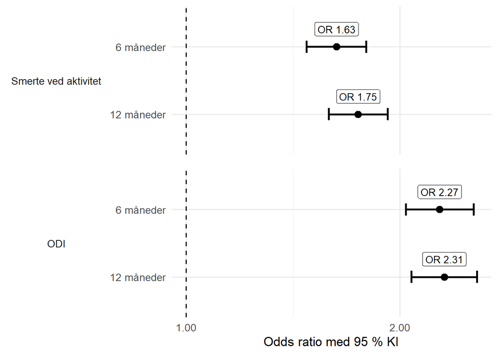

```r
or_plot_odi <- summary(
  or_odi$contrasts,
  infer = TRUE,
  type = "response"
) |>
  as.data.frame() |>
  mutate(
    utfall = "ODI",
    tidspunkt = factor(tidspunkt, levels = c("12 måneder", "6 måneder")),
    label = sprintf("OR %.2f", odds.ratio)
  )

or_plot_activity <- summary(
  or_activity$contrasts,
  infer = TRUE,
  type = "response"
) |>
  as.data.frame() |>
  mutate(
    utfall = "Smerte ved aktivitet",
    tidspunkt = factor(tidspunkt, levels = c("12 måneder", "6 måneder")),
    label = sprintf("OR %.2f", odds.ratio)
  )

or_plot_stacked <- bind_rows(
  or_plot_activity,
  or_plot_odi
) |>
  mutate(
    utfall = factor(
      utfall,
      levels = c("Smerte ved aktivitet", "ODI")
    )
  )

ggplot(
  or_plot_stacked,
  aes(
    y = tidspunkt,
    x = odds.ratio,
    xmin = lower.CL,
    xmax = upper.CL
  )
) +
  geom_vline(
    xintercept = 1,
    linetype = "dashed"
  ) +
  geom_errorbarh(
    height = 0.18,
    linewidth = 0.9
  ) +
  geom_point(
    size = 3
  ) +
  geom_label(
    aes(label = label),
    vjust = -0.8,
    size = 3.5,
    label.size = 0.2
  ) +
  scale_x_log10(
    breaks = c(0.25, 0.5, 1, 2, 4, 8),
    labels = label_number(accuracy = 0.01)
  ) +
  facet_grid(
    utfall ~ .,
    switch = "y"
  ) +
  labs(
    x = "Odds ratio med 95 % KI",
    y = NULL
  ) +
  theme_minimal(base_size = 13) +
  theme(
    strip.placement = "outside",
    strip.text.y.left = element_text(angle = 0),
    panel.spacing.y = unit(1, "lines")
  )
```